# Housing Data Analysis

```r
# Deals with Scientific notation in Plots
options(scipen = 999)
# Useful functions
library(tidyverse)
#Import Data
ames.dirty <- read.csv("~/School_Work/F19/CPSD/Group_Proj/STA4102_Project/Data/AmesHousing.csv")
ames.clean <-read.csv("~/School_Work/F19/CPSD/Group_Proj/STA4102_Project/Data/cleaned_data.csv")
```

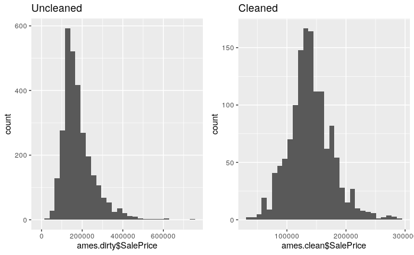

```r
fig1 <- ggplot(data = ames.dirty) +
  geom_histogram(mapping = aes(x = ames.dirty$SalePrice )) +
  ggtitle("Uncleaned")
fig2 <- ggplot(data = ames.clean) +
  geom_histogram(mapping = aes(x = ames.clean$SalePrice)) +
  ggtitle("Cleaned")
cowplot::plot_grid(fig1, fig2)
```

Now we will continue our analysis using only the clean version of the dataset. First we will look for any outliers

```r
na_count <-sapply(ames.clean, function(y) sum(is.na(y)))
print("Sum of the NA values in each column: ")
```

```
[1] "Sum of the NA values in each column: "
```

```r
na_count
```

```
              X           Order             PID     MS.SubClass       MS.Zoning
              0               0               0               0               0
   Lot.Frontage        Lot.Area          Street           Alley       Lot.Shape
            234               0               0            1272               0
   Land.Contour       Utilities      Lot.Config      Land.Slope    Neighborhood
              0               0               0               0               0
    Condition.1     Condition.2       Bldg.Type     House.Style    Overall.Qual
              0               0               0               0               0
   Overall.Cond      Year.Built  Year.Remod.Add      Roof.Style       Roof.Matl
              0               0               0               0               0
   Exterior.1st    Exterior.2nd    Mas.Vnr.Type    Mas.Vnr.Area      Exter.Qual
              0               0               0               5               0
     Exter.Cond      Foundation       Bsmt.Qual       Bsmt.Cond   Bsmt.Exposure
              0               0              47              47              47
 BsmtFin.Type.1    BsmtFin.SF.1  BsmtFin.Type.2    BsmtFin.SF.2     Bsmt.Unf.SF
             47               0              47               0               0
  Total.Bsmt.SF         Heating      Heating.QC     Central.Air      Electrical
              0               0               0               0               0
    X1st.Flr.SF     X2nd.Flr.SF Low.Qual.Fin.SF     Gr.Liv.Area  Bsmt.Full.Bath
              0               0               0               0               0
 Bsmt.Half.Bath       Full.Bath       Half.Bath   Bedroom.AbvGr   Kitchen.AbvGr
              0               0               0               0               0
   Kitchen.Qual   TotRms.AbvGrd      Functional      Fireplaces    Fireplace.Qu
              0               0               0               0             869
    Garage.Type   Garage.Yr.Blt   Garage.Finish     Garage.Cars     Garage.Area
             89              89              89               0               0
    Garage.Qual     Garage.Cond     Paved.Drive    Wood.Deck.SF   Open.Porch.SF
             89              89               0               0               0
 Enclosed.Porch     X3Ssn.Porch    Screen.Porch       Pool.Area         Pool.QC
              0               0               0               0            1359
          Fence    Misc.Feature        Misc.Val         Mo.Sold         Yr.Sold
           1012            1296               0               0               0
      Sale.Type  Sale.Condition       SalePrice
              0               0               0
```

From the above output we can see that some of our columns contain a lot of missing values. We have some missing values, namely:

- Lot Frontage (Continuous): Linear feet of street connected to property
  - All of the porperty touching the street.
- Alley (Nominal): Type of alley access to property
  - Grvl Gravel
  - Pave Paved
  - NA No alley access

```r
# Store location of NA values for Lot.Frontage
na_frontage <- is.na(ames.clean$Lot.Frontage)
ames.clean[na_frontage,]
```

|  | X | Order | PID | MS.SubClass | MS.Zoning | Lot.Frontage | Lot.Area | Street | Alley | Lot.Shape | Land.Contour | Utilities | Lot.Config | Land.Slope | Neighborhood | Condition.1 | Condition.2 | Bldg.Type | House.Style | Overall.Qual | Overall.Cond | Year.Built | Year.Remod.Add | Roof.Style | Roof.Matl | Exterior.1st | Exterior.2nd | Mas.Vnr.Type | Mas.Vnr.Area | … |
| --- | --- | --- | --- | --- | --- | --- | --- | --- | --- | --- | --- | --- | --- | --- | --- | --- | --- | --- | --- | --- | --- | --- | --- | --- | --- | --- | --- | --- | --- | --- |
| 5 | 5 | 12 | 527165230 | 20 | RL | NA | 7980 | Pave | NA | IR1 | Lvl | AllPub | Inside | Gtl | Gilbert | Norm | Norm | 1Fam | 1Story | 6 | 7 | 1992 | 2007 | Gable | CompShg | HdBoard | HdBoard | None | 0 | … |
| 9 | 9 | 24 | 527402200 | 20 | RL | NA | 11241 | Pave | NA | IR1 | Lvl | AllPub | CulDSac | Gtl | NAmes | Norm | Norm | 1Fam | 1Story | 6 | 7 | 1970 | 1970 | Gable | CompShg | Wd Sdng | Wd Sdng | BrkFace | 180 | … |
| 10 | 10 | 25 | 527402250 | 20 | RL | NA | 12537 | Pave | NA | IR1 | Lvl | AllPub | CulDSac | Gtl | NAmes | Norm | Norm | 1Fam | 1Story | 5 | 6 | 1971 | 2008 | Gable | CompShg | VinylSd | VinylSd | None | 0 | … |
| 26 | 26 | 58 | 528250100 | 80 | RL | NA | 7750 | Pave | NA | IR1 | Lvl | AllPub | Inside | Gtl | Gilbert | Norm | Norm | 1Fam | SLvl | 7 | 5 | 2000 | 2000 | Gable | CompShg | VinylSd | VinylSd | None | 0 | … |
| 35 | 35 | 87 | 532377060 | 20 | RL | NA | 9819 | Pave | NA | IR1 | Lvl | AllPub | Inside | Gtl | Sawyer | Norm | Norm | 1Fam | 1Story | 5 | 5 | 1967 | 1967 | Gable | CompShg | MetalSd | MetalSd | BrkFace | 31 | … |
| 37 | 37 | 89 | 532378110 | 20 | RL | NA | 6897 | Pave | NA | IR1 | Lvl | AllPub | Corner | Gtl | Sawyer | Norm | Norm | 1Fam | 1Story | 5 | 8 | 1962 | 2010 | Gable | CompShg | HdBoard | HdBoard | None | 0 | … |
| 44 | 44 | 104 | 533223100 | 160 | FV | NA | 2403 | Pave | NA | IR1 | Lvl | AllPub | FR2 | Gtl | Somerst | Norm | Norm | TwnhsE | 2Story | 7 | 5 | 2003 | 2003 | Gable | CompShg | VinylSd | VinylSd | None | 0 | … |
| 47 | 47 | 109 | 533352170 | 60 | RL | NA | 13517 | Pave | NA | IR1 | Lvl | AllPub | CulDSac | Gtl | Sawyer | RRAe | Norm | 1Fam | 2Story | 6 | 8 | 1976 | 2005 | Gable | CompShg | HdBoard | Plywood | BrkFace | 289 | … |
| 51 | 51 | 119 | 534251320 | 20 | RL | NA | 9790 | Pave | NA | Reg | Lvl | AllPub | Inside | Gtl | NWAmes | Feedr | Norm | 1Fam | 1Story | 6 | 5 | 1963 | 1963 | Hip | CompShg | HdBoard | HdBoard | BrkFace | 451 | … |
| 54 | 54 | 124 | 534403410 | 80 | RL | NA | 14112 | Pave | NA | IR1 | Lvl | AllPub | Corner | Gtl | NAmes | Norm | Norm | 1Fam | SLvl | 5 | 7 | 1964 | 1964 | Hip | CompShg | Wd Sdng | HdBoard | BrkFace | 86 | … |

[output cut: 224 more lines]

Now we will look at the numeric columns specifically.

```r
# Grab all the numeric columns
# Find the columns which are numeric
numeric_cols <- sapply(ames.clean, is.numeric)
#Now store the numeric columns as its own list
clean_numeric <- ames.clean[,numeric_cols]
# Print column names
colnames(clean_numeric)
```

```
 [1] "X"               "Order"           "PID"             "MS.SubClass"
 [5] "Lot.Frontage"    "Lot.Area"        "Overall.Qual"    "Overall.Cond"
 [9] "Year.Built"      "Year.Remod.Add"  "Mas.Vnr.Area"    "BsmtFin.SF.1"
[13] "BsmtFin.SF.2"    "Bsmt.Unf.SF"     "Total.Bsmt.SF"   "X1st.Flr.SF"
[17] "X2nd.Flr.SF"     "Low.Qual.Fin.SF" "Gr.Liv.Area"     "Bsmt.Full.Bath"
[21] "Bsmt.Half.Bath"  "Full.Bath"       "Half.Bath"       "Bedroom.AbvGr"
[25] "Kitchen.AbvGr"   "TotRms.AbvGrd"   "Fireplaces"      "Garage.Yr.Blt"
[29] "Garage.Cars"     "Garage.Area"     "Wood.Deck.SF"    "Open.Porch.SF"
[33] "Enclosed.Porch"  "X3Ssn.Porch"     "Screen.Porch"    "Pool.Area"
[37] "Misc.Val"        "Mo.Sold"         "Yr.Sold"         "SalePrice"
```

```r
length(clean_numeric)
```

```
[1] 40
```

Description of the numeric columns:

1. X - Need to drop useless index variable
2. Order - Index variable of original dataset
3. PID (Nominal): Parcel identification number - can be used with city web site for parcel review.
4. MS SubClass (Nominal): Identifies the type of dwelling involved in the sale.
5. Lot Frontage (Continuous): Linear feet of street connected to property
6. Lot Area (Continuous): Lot size in square feet
7. Overall Qual (Ordinal): Rates the overall material and finish of the house
8. Overall Cond (Ordinal): Rates the overall condition of the house
9. Year Built (Discrete): Original construction date
10. Year Remod/Add (Discrete): Remodel date (same as construction date if no remodeling or additions)
11. Mas Vnr Area (Continuous): Masonry veneer area in square feet
12. BsmtFin SF 1 (Continuous): Type 1 finished square feet
13. BsmtFin SF 2 (Continuous): Type 2 finished square feet
14. Bsmt Unf SF (Continuous): Unfinished square feet of basement area
15. Total Bsmt SF (Continuous): Total square feet of basement area
16. 1st flr sf (continuous): first floor square feet
17. 2nd Flr SF (Continuous) : Second floor square feet
18. Low Qual Fin SF (Continuous): Low quality finished square feet (all floors)
19. Gr Liv Area (Continuous): Above grade (ground) living area square feet
21. Bsmt Half Bath (Discrete): Basement half bathrooms
22. Full Bath (Discrete): Full bathrooms above grade
23. Half Bath (Discrete): Half baths above grade
24. Bedroom (Discrete): Bedrooms above grade (does NOT include basement bedrooms)
25. Kitchen (Discrete): Kitchens above grade
26. TotRmsAbvGrd (Discrete): Total rooms above grade (does not include bathrooms)
27. Fireplaces (Discrete): Number of fireplaces
28. Garage Yr Blt (Discrete): Year garage was built
29. Garage Cars (Discrete): Size of garage in car capacity
30. Garage Area (Continuous): Size of garage in square feet
31. Wood Deck SF (Continuous): Wood deck area in square feet
32. Open Porch SF (Continuous): Open porch area in square feet
33. Enclosed Porch (Continuous): Enclosed porch area in square feet
34. 3-Ssn Porch (Continuous): Three season porch area in square feet
35. Screen Porch (Continuous): Screen porch area in square feet
36. Pool Area (Continuous): Pool area in square feet
37. Misc Val (Continuous): $Value of miscellaneous feature
38. Mo Sold (Discrete): Month Sold (MM)
39. Yr Sold (Discrete): Year Sold (YYYY)
40. SalePrice (Continuous): Sale price